# 10_analysis

Victor Yuan

April 21, 2019

This is for analysing the scRNAseq data # 1.0 Libraries and Data

```r
set.seed(2019)
library(readxl) # read data in
library(plyr)
library(stringr)
library(knitr);library(kableExtra) # for displaying pretty tables
library(dplyr)
library(Seurat) # V3
```

```r
library(readr)
library(ggplot2)
library(cowplot)
library(tidyr)
library(monocle)
library(slingshot)
library(RColorBrewer)
library(scales)
source('../plot_genes_branched_heatmap_vyedit.R')

troph <- readRDS('../../data/interim/02_troph_merge.rds')
```

# 2.0 Validate hits

First subset to trophoblast

## 2.1 List of hits

Obtained from Microarray results folder

### Violin plots

```r
hitlist <- read_xlsx('../../data/microarray results/2019-03-19 currated scRNA-seq gene list.xlsx')
hitlist <- hitlist %>% gather(key = 'Geneset', value = 'Gene') %>% filter(!is.na(Gene))

#updated hit list:
top_20 <- read.csv('../../data/microarray results/topups_Oxygen20_1 2.csv') %>% as_tibble()
top_1 <- read.csv('../../data/microarray results/topdowns_Oxygen20_1.csv') %>% as_tibble()

x <- top_20 %>% slice(1:15) %>% select(SYMBOL) %>% mutate(Geneset = 'Top Upregulated (20%)')
y <- top_1%>% slice(1:15) %>% select(SYMBOL) %>% mutate(Geneset = 'Top Upregulated (1%)')
top <- bind_rows(x, y) %>% rename(Gene = SYMBOL) %>% select(Geneset, Gene)
```

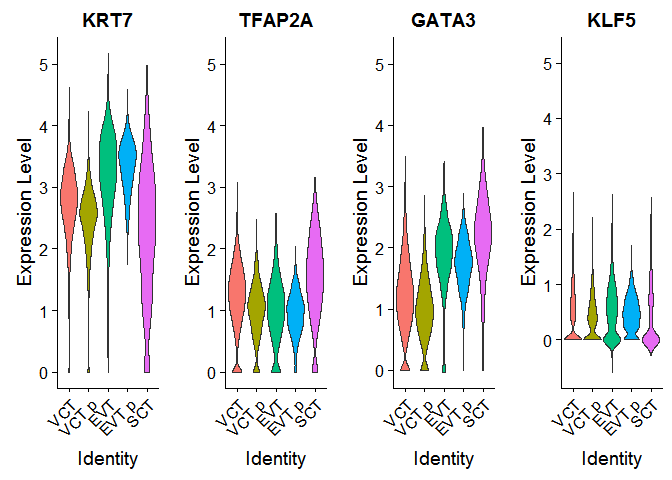

```r
# combine updated to old hit list
hitlist <- hitlist %>% filter(!Geneset %in% c('Target High', 'Target Low')) %>% bind_rows(top)

# order levels to plot by
Idents(troph) <- factor(as.character(troph$celltype),
                        levels = c('VCT', 'VCT p', 'EVT', 'EVT p', 'SCT'))

#violin plots
VlnPlot(object = troph, features = hitlist$Gene[hitlist$Geneset=='Troph (general)'],
        pt.size = F, ncol = 4, same.y.lims =  T)
```

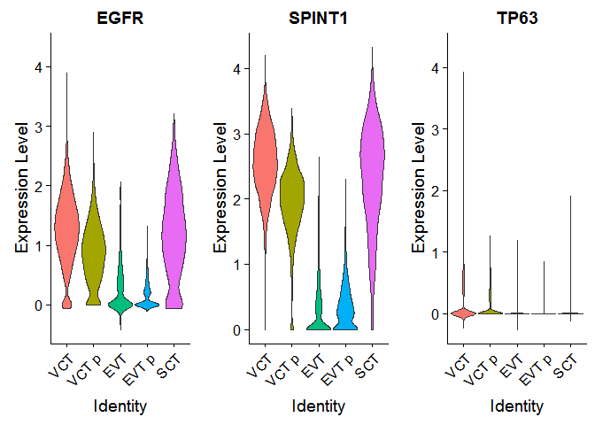

```r
VlnPlot(object = troph, features = hitlist$Gene[hitlist$Geneset=='CTB'],
        pt.size = F, same.y.lims =  T)
```

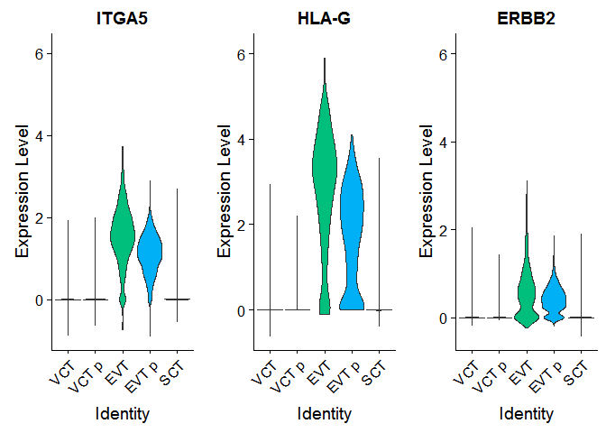

```r
VlnPlot(object = troph, features = hitlist$Gene[hitlist$Geneset=='Dist CCTB'],
        pt.size = F, same.y.lims =  T)
```

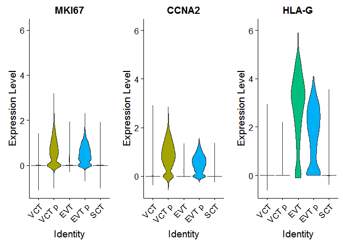

```r
VlnPlot(object = troph, features = hitlist$Gene[hitlist$Geneset=='Prox CCTB'],
        pt.size = F, same.y.lims =  T)
```

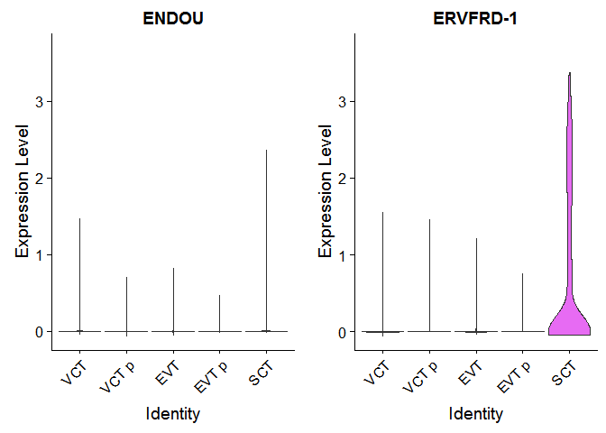

```r
VlnPlot(object = troph, features = hitlist$Gene[hitlist$Geneset=='Syn Pre CTB'],
        pt.size = F, same.y.lims =  T)
```

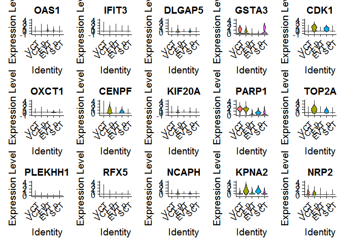

```r
VlnPlot(object = troph, features = hitlist$Gene[hitlist$Geneset=='Top Upregulated (20%)'],
        pt.size = F, same.y.lims =  T, ncol = 5)
```

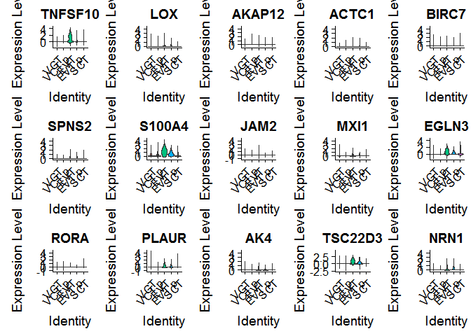

```r
VlnPlot(object = troph, features = hitlist$Gene[hitlist$Geneset=='Top Upregulated (1%)'],
        pt.size = F, same.y.lims =  T, ncol = 5)
```

### heatmap

```r
Idents(troph) <- 'celltype'
#plot average expression
average_exp <- AverageExpression(object = troph, return.seurat = T)
```

```
## Finished averaging RNA for cluster EVT
```

```
## Finished averaging RNA for cluster VCT p
```

```
## Finished averaging RNA for cluster SCT
```

```
## Finished averaging RNA for cluster VCT
```

```
## Finished averaging RNA for cluster EVT p
```

```
## Finished averaging integrated for cluster EVT
```

```
## Finished averaging integrated for cluster VCT p
```

```
## Finished averaging integrated for cluster SCT
```

```
## Finished averaging integrated for cluster VCT
```

```
## Finished averaging integrated for cluster EVT p
```

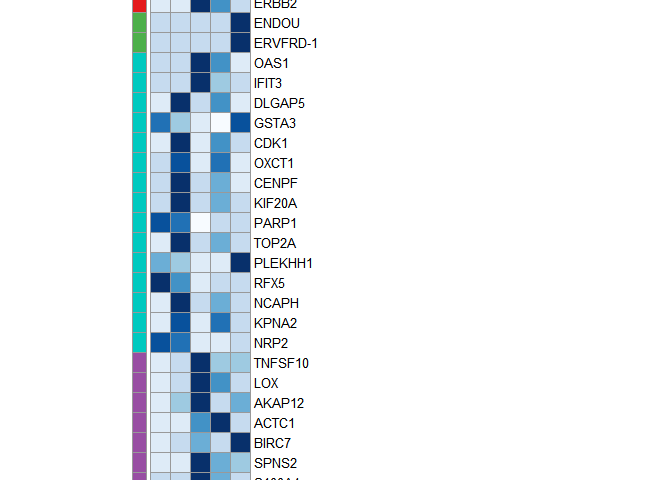

```r
ave_exp_mat <- average_exp@assays$integrated@scale.data[,] %>% as.data.frame()

library(pheatmap)
#create annotation dataframe for genes
row_label <- as.data.frame(hitlist)
row_label$Gene <- make.unique(row_label$Gene)
rownames(row_label) <- gsub('\\.', '-', row_label$Gene)
row_label$Geneset <- factor(row_label$Geneset,
                            levels = c('Troph (general)', 'CTB', 'Dist CCTB', 'Prox CCTB',
                                       'Syn Pre CTB', 'Top Upregulated (20%)', 'Top Upregulated (1%)'))

row_label <- row_label[intersect(rownames(row_label), rownames(ave_exp_mat)),]
ave_exp_mat <- ave_exp_mat[rownames(row_label),]

colors_heat <- list(
  Geneset = c('Troph (general)' = 'grey',
              'CTB' = '#FFEC23',
              'Dist CCTB' = '#E41A1C',
              'Prox CCTB' = '#FF8064',
              'Syn Pre CTB' = '#4DAF4A',
              'Top Upregulated (20%)' = '#00C9BF',
              'Top Upregulated (1%)' = '#984EA3')
)

pheatmap(ave_exp_mat[,c('VCT', 'VCT p', 'EVT', 'EVT p', 'SCT')],
         cluster_rows = F, cluster_cols = F,
         annotation_row = row_label[,'Geneset',F],
         annotation_colors = colors_heat,
         color = RColorBrewer::brewer.pal(9, "Blues"),
         cellwidth = 15, cellheight = 15)
```

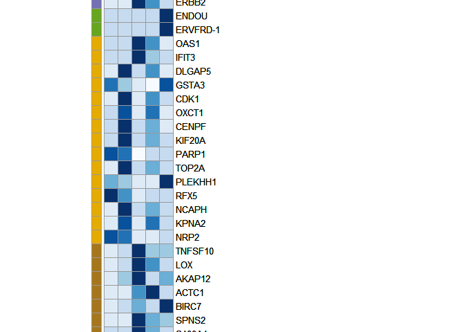

```r
colors_heat2 <- RColorBrewer::brewer.pal(7, 'Dark2')
names(colors_heat2) <- c('Troph (general)', 'CTB', 'Dist CCTB', 'Prox CCTB',
                         'Syn Pre CTB', 'Top Upregulated (20%)', 'Top Upregulated (1%)')

heatmap_plot <- pheatmap(ave_exp_mat[,c('VCT', 'VCT p', 'EVT', 'EVT p', 'SCT')],
         cluster_rows = F, cluster_cols = F,
         annotation_row = row_label[,'Geneset',F],
         annotation_colors = list('Geneset' = colors_heat2),
         color = RColorBrewer::brewer.pal(9, "Blues"),
         cellwidth = 15, cellheight = 15)
heatmap_plot
```

pdf(‘../../outs/fig5c.pdf’, height = 10) heatmap_plot dev.off()

# 3.0 Pseudotime

Note that because we are importing seurat merged data, we have to set the `expressionFamily` argument as ‘gaussianff’. Then, in following functions, when possible we must specify the arguments `norm_method` = ‘none’ and `pseudo_expr` = 0.

## 3.1 Import into monocle

```r
# import into monocle object
#Extract data, phenotype data, and feature data from the SeuratObject
troph_data <- as(as.matrix(troph@assays$integrated@data), 'sparseMatrix')

pd <- new('AnnotatedDataFrame', data = troph@meta.data)

fData <- data.frame(gene_short_name = row.names(troph_data), row.names = row.names(troph_data))
fd <- new('AnnotatedDataFrame', data = fData)

#Construct monocle object
monocle_cds <- newCellDataSet(troph_data,
                         phenoData = pd,
                         featureData = fd,
                         lowerDetectionLimit = 0.5,
                         expressionFamily = uninormal())

# process, not necessary unless using negbinomial
#monocle_cds <- estimateSizeFactors(monocle_cds)
#monocle_cds <- estimateDispersions(monocle_cds) # not neessary for gaussian data

# remove genes with very low expression (noninformative)
#monocle_cds <- detectGenes(monocle_cds, min_expr = 0.1)

# sellect a minimum number of cells expressing a gene as a threshold
#fData(monocle_cds)$use_for_ordering <-
#  fData(monocle_cds)$num_cells_expressed > 0.05 * ncol(monocle_cds)
```

## 3.2 Create trajectory

### Ordering based on cluster DEGs

Here we are finding clusters on a reduced dimensional projection (PCA -> TSNE), then clustering (‘density-peak’), then finding the top 1000 differentially expressed genes, then performing the pseudotime analysis on those genes. This is the recommended approach from the documentation.

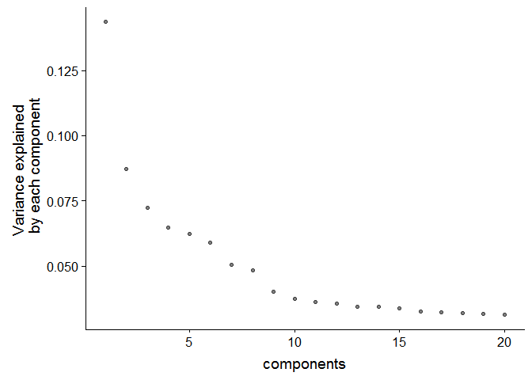

```r
# select number of principal components to use for pseudotime
plot_pc_variance_explained(cds = monocle_cds, max_components = 20, return_all = F,
                           pseudo_expr = 0, norm_method = 'none') # required argumnets for gaussianff
```

```r
set.seed(2019)
monocle_cds <- reduceDimension(monocle_cds, max_components = 2,
                               norm_method = 'none', pseudo_expr = 0,
                               num_dim = 10, reduction_method = 'tSNE', verbose = T)
```

```
## Remove noise by PCA ...
```

```
## Reduce dimension by tSNE ...
```

```r
# run density peak clustering on reduced projection
monocle_cds <- clusterCells(monocle_cds, rho_threshold = 2,
                         delta_threshold = 10,
                         skip_rho_sigma = T,
                         verbose = F)
```

```
## Distance cutoff calculated to 5.184694
```

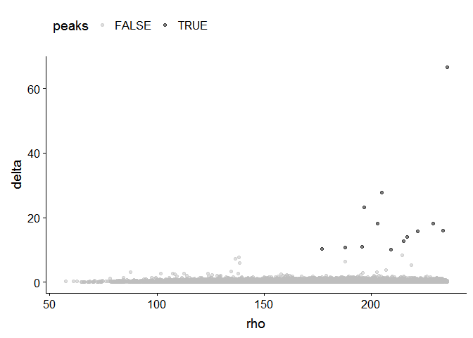

```r
#  this plot can help us decide number of clusters
plot_rho_delta(monocle_cds, rho_threshold = 2, delta_threshold = 10)
```

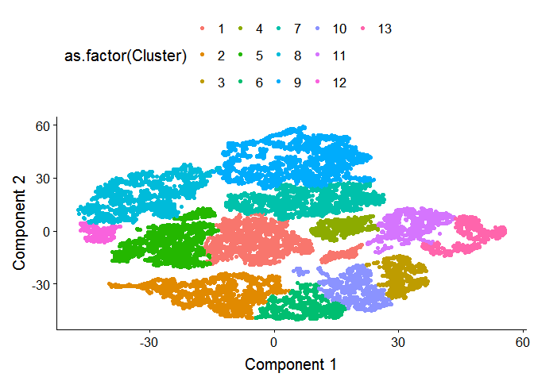

```r
plot_cell_clusters(monocle_cds, color_by = 'as.factor(Cluster)')
```

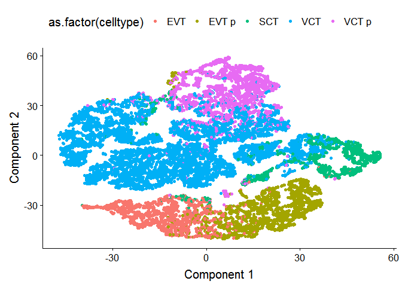

```r
plot_cell_clusters(monocle_cds, color_by = 'as.factor(celltype)')
```

Run DEG on clusters

~45 minutes with 24 cores

```r
# find differentially expressed genes between all clusters
clustering_DEG_genes <- differentialGeneTest(monocle_cds,
                                             fullModelFormulaStr = '~Cluster',
                                             cores = 24)
```

saveRDS(clustering_DEG_genes, ‘../../data/interim/clustering_DEG_genes.rds’)

```r
clustering_DEG_genes <- readRDS('../../data/interim/clustering_DEG_genes.rds')

# select top 1000 differnetially expressed genes to order the cells
ordering_genes <- row.names(clustering_DEG_genes)[order(clustering_DEG_genes$qval)][1:1000]
monocle_cds <- setOrderingFilter(monocle_cds, ordering_genes = ordering_genes)
monocle_cds <- reduceDimension(monocle_cds, method = 'DDRTree',
                               norm_method = 'none', pseudo_expr = 0)
```

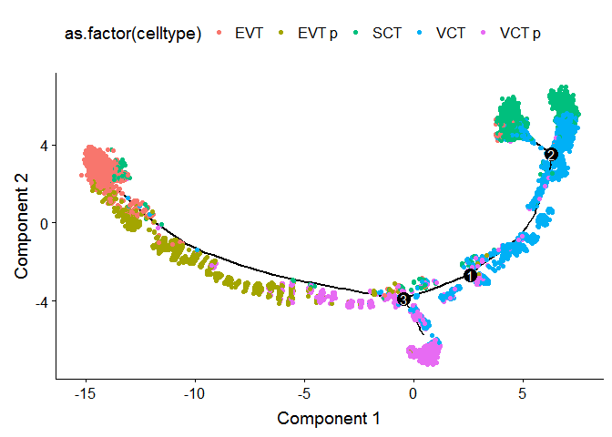

```r
monocle_cds <- orderCells(monocle_cds)
plot_cell_trajectory(monocle_cds, color_by = "as.factor(celltype)")
```

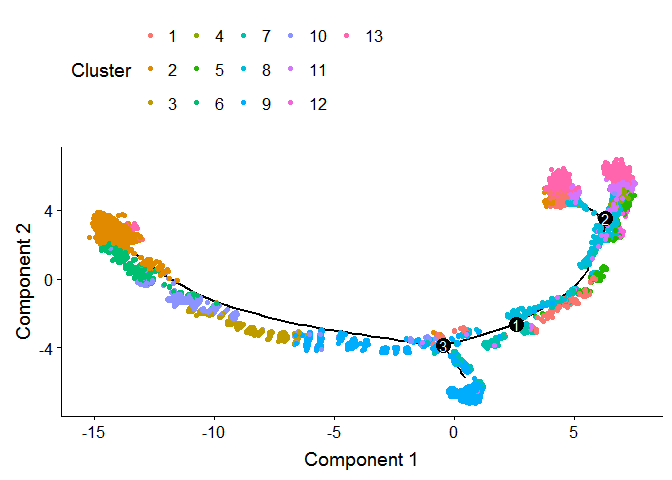

```r
plot_cell_trajectory(monocle_cds, color_by = "Cluster")
```

```r
# set root state
GM_state <- function(cds){
  if (length(unique(pData(cds)$State)) > 1){
    T0_counts <- table(pData(cds)$State, pData(cds)$celltype)[,"VCT"]
    return(as.numeric(names(T0_counts)[which
          (T0_counts == max(T0_counts))]))
  } else {
    return (1)
  }
}
monocle_cds <- orderCells(monocle_cds, root_state = GM_state(monocle_cds))
```

Pretty good.

### Based on top 1000 variable genes

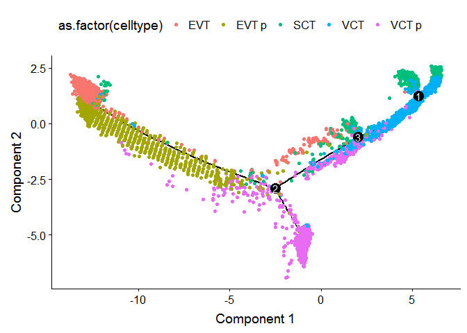

```r
top1000variable <- troph@assays$integrated@var.features[1:1000]
monocle_cds_top1000 <- setOrderingFilter(monocle_cds, ordering_genes = top1000variable)
monocle_cds_top1000 <- reduceDimension(monocle_cds_top1000, method = 'DDRTree',
                               norm_method = 'none', pseudo_expr = 0)
monocle_cds_top1000 <- orderCells(monocle_cds_top1000)
plot_cell_trajectory(monocle_cds_top1000, color_by = "as.factor(celltype)")
```

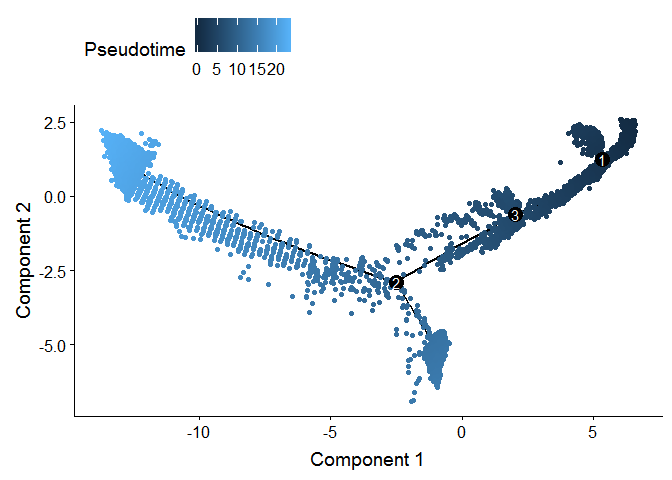

```r
plot_cell_trajectory(monocle_cds_top1000, color_by = "Pseudotime")
```

This looks pree good. Can it be better?

### Based on top 1000 DEGs between all trophoblast subtypes

```r
# find differentially expressed genes between trophoblasts
troph_DEG_genes <- differentialGeneTest(monocle_cds,
                                        fullModelFormulaStr = '~celltype',
                                        cores = 24)
```

saveRDS(troph_DEG_genes, ‘../../data/interim/troph_DEG_genes.rds’)

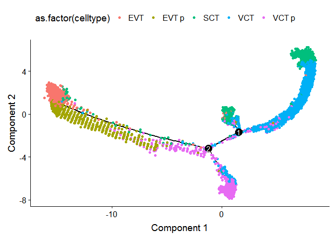

```r
troph_DEG_genes <- readRDS('../../data/interim/troph_DEG_genes.rds')

ordering_genes <- row.names(troph_DEG_genes)[order(troph_DEG_genes$qval)][1:1000]
monocle_cds_DEG <- setOrderingFilter(monocle_cds, ordering_genes = ordering_genes)
monocle_cds_DEG <- reduceDimension(monocle_cds_DEG, method = 'DDRTree',
                               norm_method = 'none', pseudo_expr = 0)
monocle_cds_DEG <- orderCells(monocle_cds_DEG)
plot_cell_trajectory(monocle_cds_DEG, color_by = "as.factor(celltype)")
```

Best so far

### Based on all genes

```r
troph_expressed_genes <- rownames(troph)[Matrix::rowMeans(troph@assays$RNA@counts) > 0.1]
length(troph_expressed_genes) # 10491
```

```
## [1] 10491
```

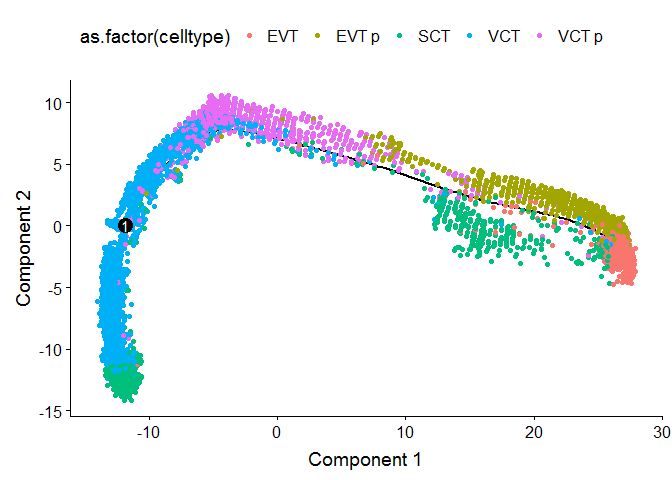

```r
ordering_genes <- troph_expressed_genes
monocle_cds_all <- setOrderingFilter(monocle_cds, ordering_genes = ordering_genes)
monocle_cds_all <- reduceDimension(monocle_cds_all, method = 'DDRTree',
                               norm_method = 'none', pseudo_expr = 0)
monocle_cds_all <- orderCells(monocle_cds_all)
plot_cell_trajectory(monocle_cds_all, color_by = "as.factor(celltype)")
```

### Based on trophoblast marker genes.

First we assign cell type by trophoblast marker genes

```r
EGFR_id <- row.names(subset(fData(monocle_cds), gene_short_name == "EGFR"))
HLAG_id <- row.names(subset(fData(monocle_cds), gene_short_name == "HLA-G"))
ENDOU_id <- row.names(subset(fData(monocle_cds), gene_short_name == "ENDOU"))
MKI67_id <- row.names(subset(fData(monocle_cds), gene_short_name == "MKI67"))


cth <- newCellTypeHierarchy()

cth <- addCellType(cth,
                   cell_type_name = "CTB",
                   classify_func = function(x) { x[EGFR_id,] >= 0.1 })

cth <- addCellType(cth,
                   cell_type_name = "CTB p", parent_cell_type_name = "CTB",
                   classify_func = function(x) { x[MKI67_id,] >= 0.1 })

cth <- addCellType(cth,
                   cell_type_name = "EVT",
                   classify_func = function(x) { x[HLAG_id,] >= 0.1 })

cth <- addCellType(cth,
                   cell_type_name = "EVT p", parent_cell_type_name = "EVT",
                   classify_func = function(x) { x[MKI67_id,] >= 0.1 })

cth <- addCellType(cth,
                   cell_type_name = "STB",
                   classify_func = function(x) { x[ENDOU_id,] >= 0.1})

monocle_cds_class <- classifyCells(monocle_cds, cth)
```

Now we select additional genes that covary with these marker genes

```r
# do this on only the genes with expression over a minimum value
troph_expressed_genes <- rownames(troph)[Matrix::rowMeans(troph@assays$RNA@counts) > 0.1]
length(troph_expressed_genes) # 10491
```

```
## [1] 10491
```

```r
# find expressed genes
marker_diff <- markerDiffTable(monocle_cds_class[,],
                               cth, cores = 24)
semisup_clustering_genes <-
    row.names(subset(marker_diff, qval < 0.05))
semisup_clustering_genes <-
    row.names(marker_diff)[order(marker_diff$qval)][1:1000]
```

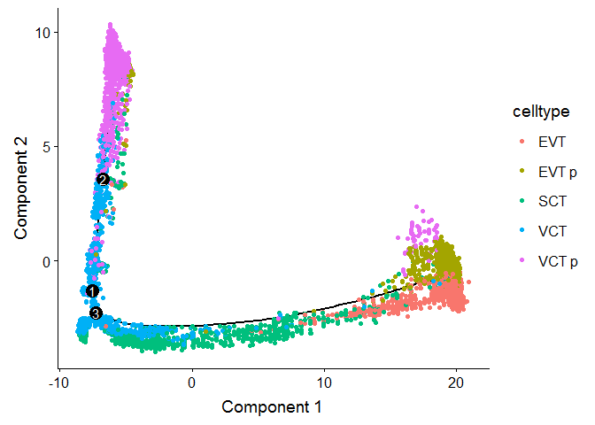

```r
monocle_cds_class <- setOrderingFilter(monocle_cds, semisup_clustering_genes)
monocle_cds_class <- reduceDimension(monocle_cds_class, max_components = 2,
    method = 'DDRTree', norm_method = 'none', pseudo_expr = 0)
monocle_cds_class <- orderCells(monocle_cds_class)
plot_cell_trajectory(monocle_cds_class, color_by = "celltype") +
    theme(legend.position = "right")
```

## 3.3 Plot gene expression along trajectory

Start with overview (fig 5a, 5b) ### Fig5a, 5b

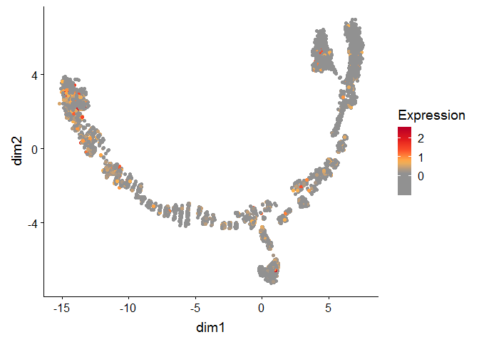

```r
cols1 <- c('#919191', '#feb24c', '#fd8d3c', '#fc4e2a', '#e31a1c')
cols2 <- c('#919191', '#919191', # greys
           '#ffeda0', '#feb24c', '#fc4e2a', # yellow/orange
           '#e31a1c', '#bd0026') # red
cols3<- c('#919191', '#919191', '#919191', # greys
          '#feb24c', '#fc4e2a', # yellow/orange
           '#e31a1c', '#bd0026') # red

# add expression data to pdata
pDat <- monocle_cds@phenoData@data %>% as_tibble %>%
  mutate(dim1 = reducedDimS(monocle_cds)[1,], dim2 = reducedDimS(monocle_cds)[2,]) %>%
  bind_cols(t(troph@assays$integrated@data[hitlist$Gene,]) %>% as.data.frame)

pDat_melt<- pDat %>% select(dim1:NRN1, celltype) %>%
  gather(key = Gene, value = Expression, -dim1, -dim2, -celltype) %>%
  left_join(hitlist, by = c('Gene'))

# plot one gene test
ggplot(pDat_melt %>% filter(Gene == 'OAS1'), aes(x = dim1, y = dim2, col = Expression)) +
  geom_point() +
  scale_color_gradientn(colours = cols3)
```

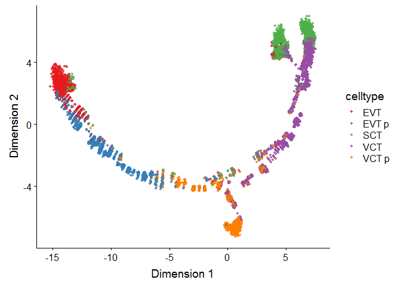

```r
# overview
fig5a <- ggplot(pDat, aes(x = dim1, y = dim2, col = celltype)) +
  geom_point(alpha = 0.7, size = 1) +
  scale_color_brewer(palette = 'Set1')+
  labs(x = 'Dimension 1', y = 'Dimension 2')
fig5a
```

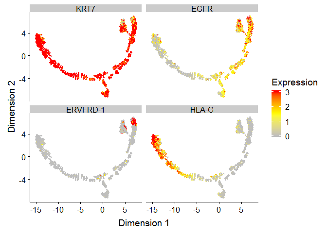

```r
# classic trophoblast markers
fig5b <- pDat_melt %>%
  filter(Gene %in% c('KRT7', 'EGFR', 'ERVFRD-1', 'HLA-G')) %>%
  mutate(Gene = factor(as.character(Gene), levels = c('KRT7', 'EGFR', 'ERVFRD-1', 'HLA-G'))) %>%
  group_by(Gene) %>%
  mutate(Expression = Expression/sd(Expression)) %>%
  ggplot(aes(x = dim1, y = dim2, col = Expression)) +
  geom_point(size = 0.8, alpha = 0.8) +
  scale_color_gradientn(colors = c('grey', 'yellow', 'red'), limits = c(0, 3), oob = squish) +
  facet_wrap(~Gene) +
  labs(x = 'Dimension 1', y = 'Dimension 2', color = 'Expression')
fig5b
```

tiff(file = ‘../../outs/fig5a.tiff’,width = 7.5, height = 5, units = ‘in’, res = 300) fig5a dev.off()

tiff(file = ‘../../outs/fig5b.tiff’,width = 9.5, height = 7, units = ‘in’, res = 300) fig5b dev.off()

Validate O2 hits

### 1%

Upregulated in 1%

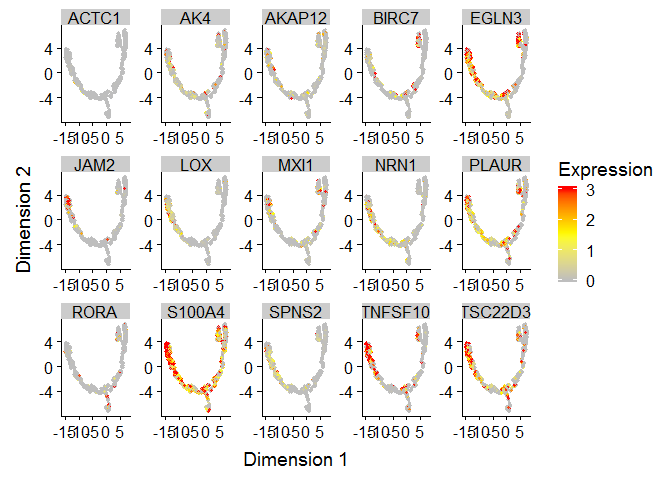

```r
library(scales)
#facet grid
fig5d <- ggplot(pDat_melt %>% filter(Geneset == 'Top Upregulated (1%)'),
                aes(x = dim1, y = dim2,
                    col = (Expression) / sd(Expression))) +
  geom_point(size = 0.8, alpha = 0.8) +
  scale_color_gradientn(colors = c('grey', 'yellow', 'red'), limits = c(0, 3), oob = squish) +
  facet_wrap(~Gene, scale = 'free', nrow = 3) +
  labs(x = 'Dimension 1', y = 'Dimension 2', color = 'Expression')
fig5d
```

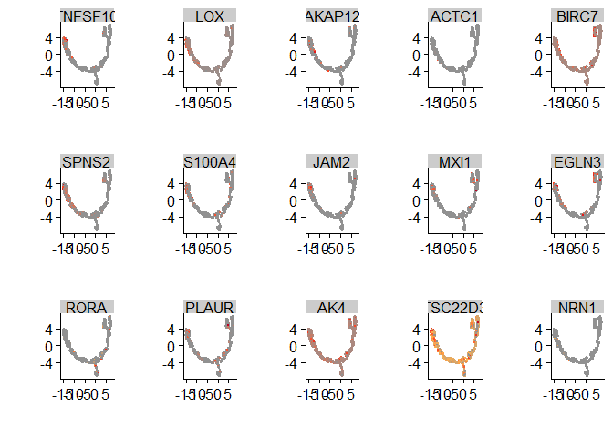

```r
### Old approach, way too tedious
# with cowplot::plot_grid()
plot_list_low <- list()

gene_ind <- hitlist %>% filter(Geneset == 'Top Upregulated (1%)') %>% pull(Gene)

  #c('LOX', 'FOXO1', 'HEY1', 'HCAR3', 'LPCAT2', 'FLT1', 'HTRA1', 'EGLN3', 'CSF1R', 'PLAUR')

for (i in 1:length(gene_ind)) {
  if(gene_ind[i] %in% c('LOX', 'ACTC1', 'BIRC7', 'SPNS2', 'AK4')) {
    cols <-  c('#919191', # greys
            '#fc4e2a', # /orange
           '#e31a1c', '#bd0026') # red # high contrast color scale
  } else if (gene_ind[i] %in% c('TNFSF10', 'S100A4', 'JAM2', 'EGLN3')) {
    cols <- c('#919191', '#919191', '#919191', # greys
            '#fc4e2a', # /orange
           '#e31a1c', '#bd0026')
  } else if (gene_ind[i] %in% c('RORA', 'AK4', 'TSC22D3', 'NRN1')) {
    cols <- c('#919191', '#919191', '#919191', # greys
            '#FEB24C', '#fc4e2a', # /orange
           '#e31a1c', '#bd0026')
  } else {
    cols <- c('#919191', '#919191',  # greys
            '#fc4e2a', # /orange
           '#e31a1c', '#bd0026') # red
  }

  plot_list_low[[i]] <-
    ggplot(pDat_melt %>% filter(Gene == gene_ind[i]), aes(x = dim1, y = dim2, col = Expression)) +
    geom_point(size = 0.2, alpha = 1) +
    scale_color_gradientn(colours = cols) + # red
    facet_wrap(~Gene, scale = 'free') +
    labs(x = '', y = '', col = '') +
    theme(legend.position = 'none')
}

plot_grid(plotlist = plot_list_low, nrow = 3)
```

tiff(file = ‘../../outs/fig5d.tiff’, width = 11, height = 7, units = ‘in’, res = 300) fig5d dev.off()

### 20%

Upregulated in 20%

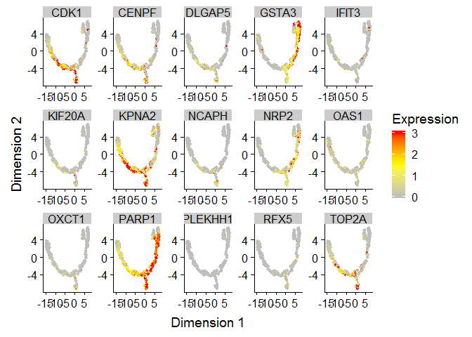

```r
fig5e <- ggplot(pDat_melt %>% filter(Geneset == 'Top Upregulated (20%)'),
                aes(x = dim1, y = dim2, col = Expression / sd(Expression))) +
  geom_point(size = 0.8, alpha = 1) +
  scale_color_gradientn(colors = c('grey', 'yellow', 'red'), limits = c(0, 3), oob = squish) +
  facet_wrap(~Gene, scale = 'free', nrow = 3) +
  labs(x = 'Dimension 1', y = 'Dimension 2', color = 'Expression')
fig5e
```

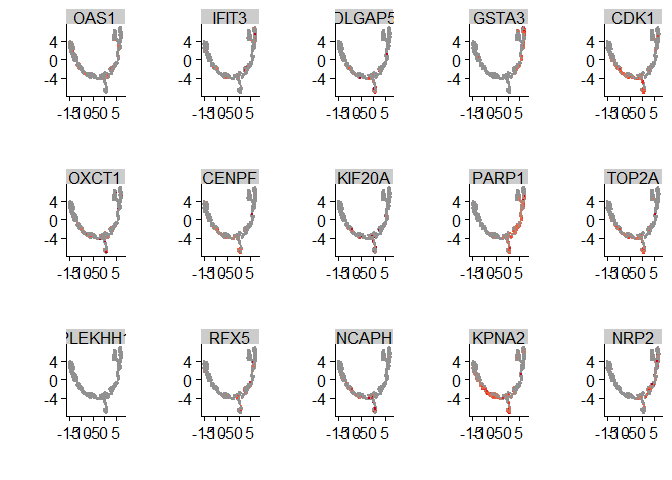

```r
# with cowplot::plot_grid()
plot_list_high <- list()
gene_ind <- c('PEG10', 'ANK3', 'CDC20', 'PARP1', 'GSTA3',
              'CCNA2', 'NRP2', 'CDK1', 'TOP2A', 'CCNB1')
gene_ind <- pDat_melt %>% filter(Geneset == 'Top Upregulated (20%)') %>% pull(Gene) %>% unique

for (i in 1:length(gene_ind)) {
  if (gene_ind[i] %in% c('OAS1', 'GSTA3', 'CDK1')) {
    cols <- c('#919191', '#919191', '#919191', # greys
            '#fc4e2a', # /orange
           '#e31a1c', '#bd0026') # red
  } else if (gene_ind[i] %in% c('IFIT3', 'CENPF', 'PARP1', 'TOP2A', 'KPNA2', 'NRP2')){
    cols <- c('#919191', '#919191', #GREYS
              #'#FEB24C', #YELLOW
              '#fc4e2a', #ORANGE
              '#bd0026', '#bd0026') #red
  } else if(gene_ind[i] %in% c('DLGAP5', 'OXCT1', 'CENPF', 'KIF20A', 'NCAPH')){
    cols <-  c('#919191', '#919191','#919191', '#919191',#GREYS
             # '#FEB24C', #YELLOW
              '#fc4e2a', #ORAGNE
              '#bd0026', '#bd0026', '#bd0026', '#bd0026') #red
  } else {
    cols <-  c('#919191', '#919191',#GREYS
              #'#FEB24C',
              '#fc4e2a', #ORANGE
              '#bd0026', '#bd0026', '#bd0026', '#bd0026') #red
  }

  plot_list_high[[i]] <-
    ggplot(pDat_melt %>% filter(Gene == gene_ind[i]), aes(x = dim1, y = dim2, col = Expression)) +
    geom_point(size = 0.2, alpha = 1) +
    scale_color_gradientn(colours = cols) +
    facet_wrap(~Gene, scale = 'free') +
    labs(x = '', y = '', col = '') +
    theme(legend.position = 'none')
}

plot_grid(plotlist = plot_list_high, nrow = 3)
```

tiff(file = ‘../../outs/fig5e.tiff’, width = 11, height = 7, units = ‘in’, res = 300) fig5e dev.off()

## 3.4 By state

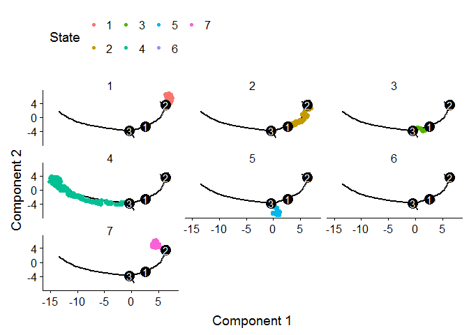

```r
plot_cell_trajectory(monocle_cds, color_by = "State") +
  facet_wrap(~State)
```

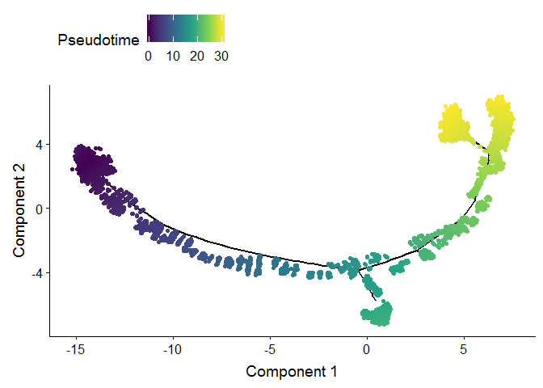

```r
plot_cell_trajectory(monocle_cds, color_by = "Pseudotime", show_branch_points  = F) +
  scale_color_viridis_c()
```

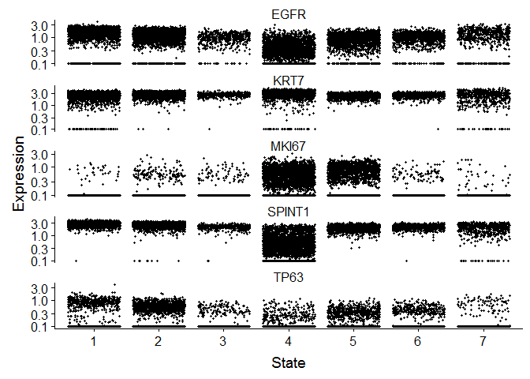

```r
# identify state containing mostly CTB cells

blast_genes <- row.names(subset(fData(monocle_cds),
                                gene_short_name %in% c("SPINT1", "TP63", "EGFR", 'MKI67', 'KRT7')))
plot_genes_jitter(monocle_cds[blast_genes,],
    grouping = "State",
    min_expr = 0.1,
    relative_expr = F)
```

pdf(‘../../outs/fig5_by_pseudotime.pdf’) plot_cell_trajectory(monocle_cds, color_by = “Pseudotime”, show_branch_points = F) + scale_color_viridis_c() dev.off()

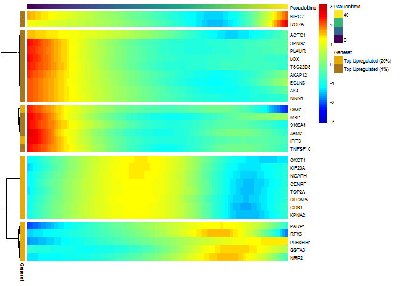

```r
to_be_tested <- hitlist %>%
  filter(Geneset %in% c('Top Upregulated (20%)', 'Top Upregulated (1%)')) %>% pull(Gene)


# row annotation
row_anno <- hitlist %>%
  filter(Geneset %in% c('Top Upregulated (20%)', 'Top Upregulated (1%)')) %>%
  select(Geneset) %>%
  as.data.frame()
rownames(row_anno) <- to_be_tested

# color annotations
# for row
geneset_cols <- RColorBrewer::brewer.pal(7, 'Dark2')
names(geneset_cols) <- c('Troph (general)', 'CTB', 'Dist CCTB', 'Prox CCTB',
                         'Syn Pre CTB', 'Top Upregulated (20%)', 'Top Upregulated (1%)')
geneset_cols <- geneset_cols[6:7]

# for columns
cell_trajectory_cols <- c('Extravillous pathway' = '#b30000', #darkred
                          'Pre-branch' = 'grey',
                          'Syncytiotrophoblast pathway' = '#003cb3') # darkblue

pseudotime_cols <- viridis_pal()(100)
names(pseudotime_cols) <- seq(0,40,length = 100)

colors_heat <- list('Geneset' = geneset_cols,
                    'Pseudotime' = pseudotime_cols)


#plot_genes_branched_heatmap_vyedit(
#  monocle_cds[to_be_tested,], branch_point = 3,
#  num_clusters = 5,
#  norm_method = 'none',
#  add_annotation_row = row_anno,
#  annotation_cols = colors_heat,
#  show_rownames = T,
#  branch_labels = c('Extravillous pathway', 'Syncytiotrophoblast pathway'),
#  return_heatmap = F)


plot_pseudotime_heatmap_vyedit(monocle_cds[to_be_tested,],
                        show_rownames = T,
                        num_clusters = 5,
                        add_annotation_row = row_anno,
                        add_annotation_col = data.frame(Pseudotime = seq(0,40, length = 100)),
                        annotation_cols = colors_heat)
```

pdf(‘../../outs/fig5_pseudotime_heatmap.pdf’, height = 4.5, width = 6)

plot_pseudotime_heatmap_vyedit(monocle_cds[to_be_tested,], show_rownames = T, num_clusters = 5, add_annotation_row = row_anno, add_annotation_col = data.frame(Pseudotime = seq(0,40, length = 100)), annotation_cols = colors_heat) dev.off()

## 3.5 Slingshot

Here I try Slingshot because it can take a reduced dimensional matrix of the cells

```r
sce <- slingshot(data = troph@reductions$umap@cell.embeddings,
                 clusterLabels = troph$celltype)
```

```
## Using full covariance matrix
```

```r
line <- getLineages(troph@reductions$umap@cell.embeddings,
                    clusterLabels = troph$celltype,
                    start.clus = 'VCT')
```

```
## Using full covariance matrix
```

```r
crv1 <- getCurves(line)
```

[output not shown]

[output cut: 304 more lines]

[output not shown]

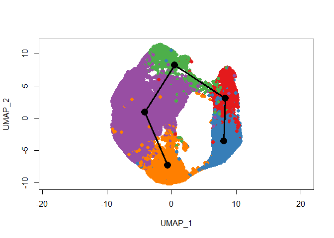

```r
plot(troph@reductions$umap@cell.embeddings[,1:2],
     col = brewer.pal(9,"Set1")[as.numeric(as.factor(troph$celltype))], asp = 1, pch = 16)
lines(line, lwd = 3, col = 'black')
```

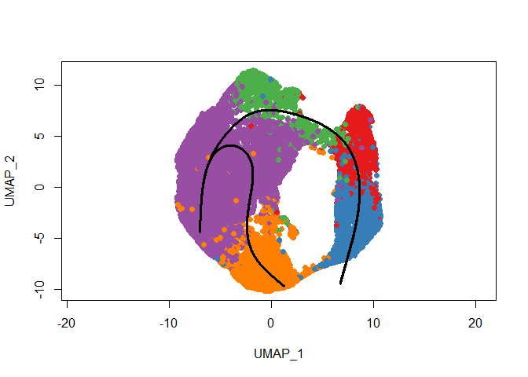

```r
plot(troph@reductions$umap@cell.embeddings[,1:2],
     col = brewer.pal(9,"Set1")[as.numeric(as.factor(troph$celltype))], asp = 1, pch = 16)
lines(crv1, lwd = 3, col = 'black')
```

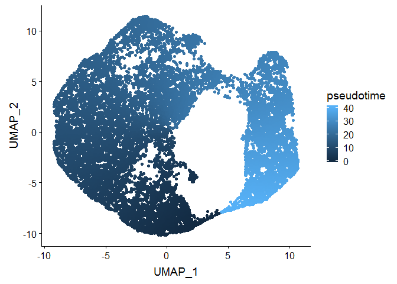

```r
pDat <- troph@meta.data %>%
  as_tibble %>%
  bind_cols(as_tibble(sce@reducedDim)) %>%
  bind_cols(as_tibble(troph@reductions$umap@cell.embeddings)) %>%
  mutate(pseudotime = slingPseudotime(sce)[,1])

ggplot(pDat, aes(x = UMAP_1, y = UMAP_2, col = pseudotime)) +
  geom_point()
```

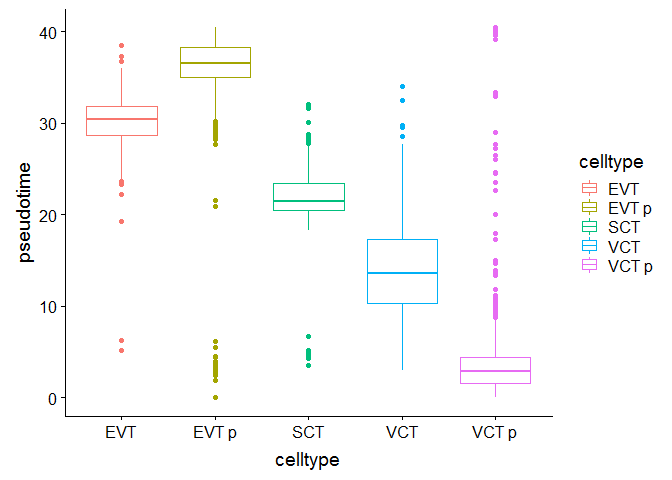

```r
ggplot(pDat, aes(x = celltype, y = pseudotime, col = celltype)) +
  geom_boxplot()
```